# What is prediction?

Jeffrey Leek

## The central dogma of prediction

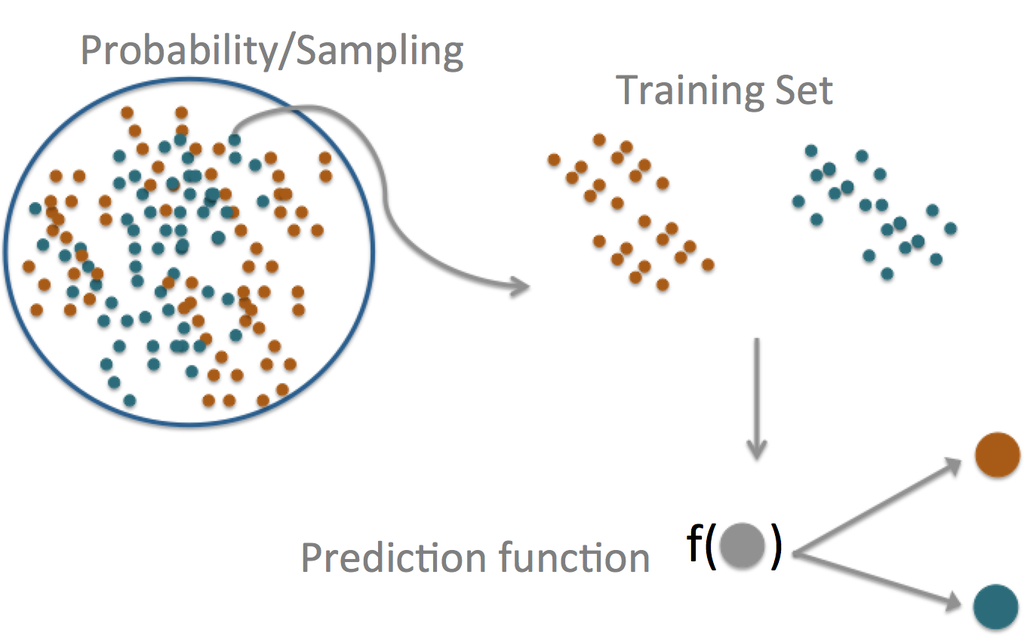

## What can go wrong

[figure not shown]

http://www.sciencemag.org/content/343/6176/1203.full.pdf

## Components of a predictor

question -> input data -> features -> algorithm -> parameters -> evaluation

## SPAM Example

question -> input data -> features -> algorithm -> parameters -> evaluation

**Start with a general question**

Can I automatically detect emails that are SPAM that are not?

**Make it concrete**

Can I use quantitative characteristics of the emails to classify them as SPAM/HAM?

## SPAM Example

question -> input data -> features -> algorithm -> parameters -> evaluation

[figure not shown]

http://rss.acs.unt.edu/Rdoc/library/kernlab/html/spam.html

## SPAM Example

question -> input data -> features -> algorithm -> parameters -> evaluation

**Dear Jeff,**

Can you send me your address so I can send you the invitation?

Thanks,

Ben

## SPAM Example

question -> input data -> features -> algorithm -> parameters -> evaluation

Dear Jeff,

Can you send me your address so I can send you the invitation?

Thanks,

Ben

Frequency of you $= 2/17 = 0.118$

## SPAM Example

question -> input data -> features -> algorithm -> parameters -> evaluation

```r
library(kernlab)
data(spam)
head(spam)
```

```
  make address  all num3d  our over remove internet order mail receive will people report addresses
1 0.00    0.64 0.64     0 0.32 0.00   0.00     0.00  0.00 0.00    0.00 0.64   0.00   0.00      0.00
2 0.21    0.28 0.50     0 0.14 0.28   0.21     0.07  0.00 0.94    0.21 0.79   0.65   0.21      0.14
3 0.06    0.00 0.71     0 1.23 0.19   0.19     0.12  0.64 0.25    0.38 0.45   0.12   0.00      1.75
4 0.00    0.00 0.00     0 0.63 0.00   0.31     0.63  0.31 0.63    0.31 0.31   0.31   0.00      0.00
5 0.00    0.00 0.00     0 0.63 0.00   0.31     0.63  0.31 0.63    0.31 0.31   0.31   0.00      0.00
6 0.00    0.00 0.00     0 1.85 0.00   0.00     1.85  0.00 0.00    0.00 0.00   0.00   0.00      0.00
  free business email  you credit your font num000 money hp hpl george num650 lab labs telnet
1 0.32     0.00  1.29 1.93   0.00 0.96    0   0.00  0.00  0   0      0      0   0    0      0
2 0.14     0.07  0.28 3.47   0.00 1.59    0   0.43  0.43  0   0      0      0   0    0      0
3 0.06     0.06  1.03 1.36   0.32 0.51    0   1.16  0.06  0   0      0      0   0    0      0
4 0.31     0.00  0.00 3.18   0.00 0.31    0   0.00  0.00  0   0      0      0   0    0      0
5 0.31     0.00  0.00 3.18   0.00 0.31    0   0.00  0.00  0   0      0      0   0    0      0
6 0.00     0.00  0.00 0.00   0.00 0.00    0   0.00  0.00  0   0      0      0   0    0      0
  num857 data num415 num85 technology num1999 parts pm direct cs meeting original project   re  edu
```

[output cut: 20 more lines]

## SPAM Example

question -> input data -> features -> algorithm -> parameters -> evaluation

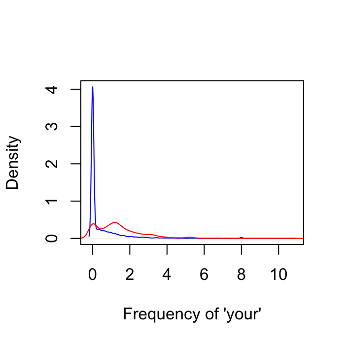

```r
plot(density(spam$your[spam$type=="nonspam"]),
     col="blue",main="",xlab="Frequency of 'your'")
lines(density(spam$your[spam$type=="spam"]),col="red")
```

## SPAM Example

question -> input data -> features -> algorithm -> parameters -> evaluation

**Our algorithm**

- Find a value $C$.
- **frequency of ‘your’ $>$ C** predict “spam”

## SPAM Example

question -> input data -> features -> algorithm -> parameters -> evaluation

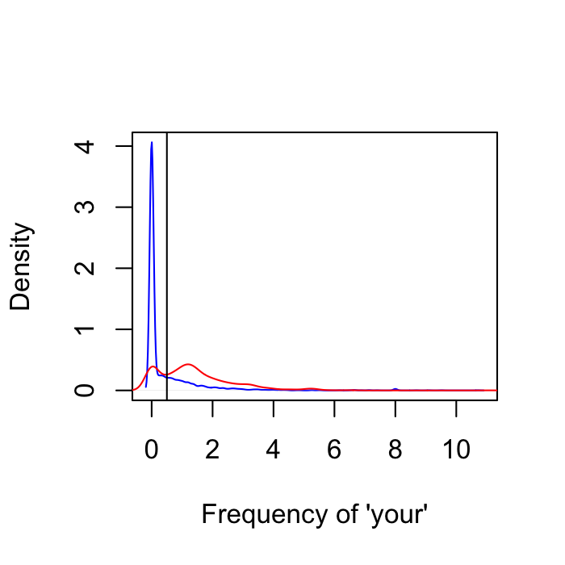

```r
plot(density(spam$your[spam$type=="nonspam"]),
     col="blue",main="",xlab="Frequency of 'your'")
lines(density(spam$your[spam$type=="spam"]),col="red")
abline(v=0.5,col="black")
```

## SPAM Example

question -> input data -> features -> algorithm -> parameters -> evaluation

```r
prediction <- ifelse(spam$your > 0.5,"spam","nonspam")
table(prediction,spam$type)/length(spam$type)
```

```
prediction nonspam   spam
   nonspam  0.4590 0.1017
   spam     0.1469 0.2923
```

Accuracy$ 0.459 + 0.292 = 0.751$